# Lab 8

STA 206 | Fall 2021

November 17, 2021

## Model Selection in Multiple Regression

When we have a large pool of $X$ variables, instead of using them all, we would prefer to choose a few subsets that give us the “best” model based on a certain criterion. In this section, we look at model selection and some commonly used selection criteria, namely, $AIC, BIC, C_p, R_a^2$ and $Press_p$. For $AIC, BIC, Press_p$, the smaller is the better. For $R_a^2$, the larger is the better. For $C_p$, good models should be close or below the line $C_p = p$.

We will look at the `realestate.txt` data: The response variable is the residential home sales prices in a mid-western city; The potential predictors are some characteristics of the home and surrounding property. Six of these predictors are quantitative and five of them are categorical.

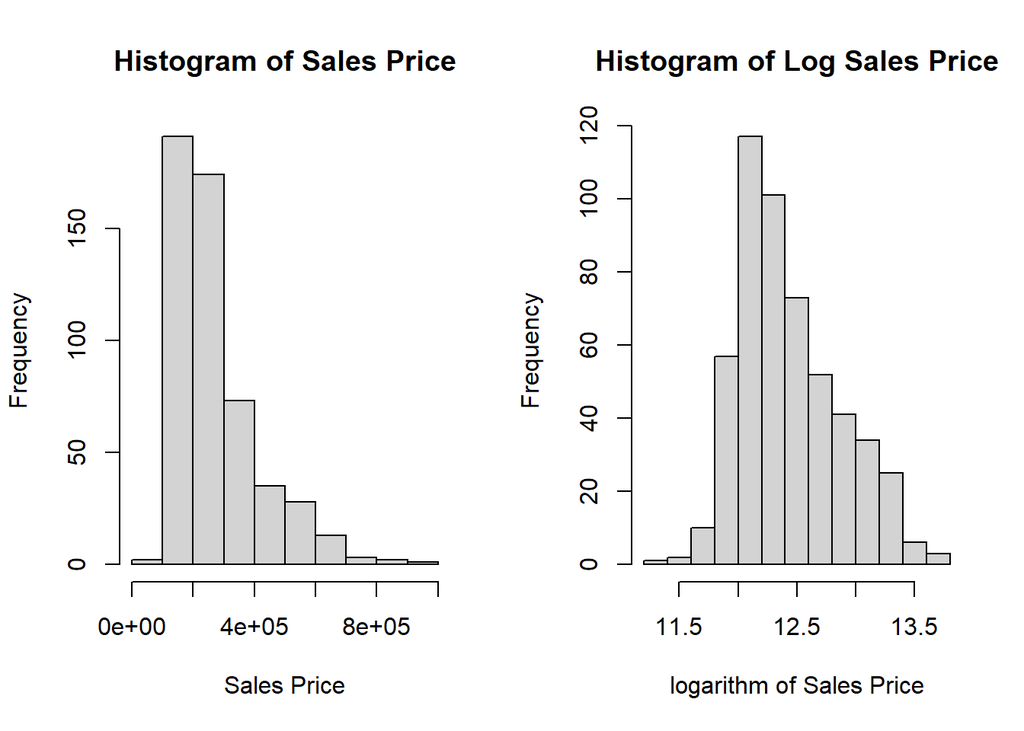

```r
data <- read.table("realestate.txt", header = T)
Y <- data[, 2]
par(mfrow = c(1, 2))
hist(Y, main = "Histogram of Sales Price", xlab = "Sales Price")
hist(log(Y), main = "Histogram of Log Sales Price", xlab = "logarithm of Sales Price")
```

```r
par(mfrow = c(1, 1))
y <- log(Y)
```

The histogram of the response variable (*sales price*) shows it is skewed to the right, so we will take the log transformation on the home sale prices.

Now, let’s look into the predictor variables:

```r
#categorical predictor variables
X_c <- data[, c(6,8,10,11,13)]
colnames(X_c) <- c("AC","pool","quality","style","hw")
#quantitative predictor variables
X_q <- data[, c(3,4,5,7,9,12)]
colnames(X_q) <- c("sqf","bedrm","bathrm","garage","year","lotsz")
```

We will use the transformed dataset from now on:

```r
#transformed dataset
d <- cbind(y,X_q,X_c)
head(d)
```

```
##          y  sqf bedrm bathrm garage year lotsz AC pool quality style hw
## 1 12.79386 3032     4      4      2 1972 22221  1    0       2     1  0
## 2 12.73670 2058     4      2      2 1976 22912  1    0       2     1  0
## 3 12.42922 1780     4      3      2 1980 21345  1    0       2     1  0
## 4 12.23320 1638     4      2      2 1963 17342  1    0       2     1  0
## 5 12.52634 2196     4      3      2 1968 21786  1    0       2     7  0
## 6 12.42118 1966     4      3      5 1972 18902  1    1       2     1  0
```

```r
str(d)
```

```
## 'data.frame':    522 obs. of  12 variables:
##  $ y      : num  12.8 12.7 12.4 12.2 12.5 ...
##  $ sqf    : int  3032 2058 1780 1638 2196 1966 2216 1597 1622 1976 ...
##  $ bedrm  : int  4 4 4 4 4 4 3 2 3 3 ...
##  $ bathrm : int  4 2 3 2 3 3 2 1 2 3 ...
##  $ garage : int  2 2 2 2 2 5 2 1 2 1 ...
##  $ year   : int  1972 1976 1980 1963 1968 1972 1972 1955 1975 1918 ...
##  $ lotsz  : int  22221 22912 21345 17342 21786 18902 18639 22112 14321 32358 ...
##  $ AC     : int  1 1 1 1 1 1 1 1 1 0 ...
##  $ pool   : int  0 0 0 0 0 1 0 0 0 0 ...
##  $ quality: int  2 2 2 2 2 2 2 2 3 3 ...
##  $ style  : int  1 1 1 1 7 1 7 1 1 1 ...
##  $ hw     : int  0 0 0 0 0 0 0 0 0 0 ...
```

Moreover, we will only use half of the data for model building (*training data*) and keep the other half for model validation (*validation data*).

```r
#split data into two halves (training and validation)
set.seed(100)
n <- nrow(d)/2
ind <- sample(1:(2*n), n, replace=FALSE)
train <- d[ind, ] #training set
valid <- d[-ind, ] #validation/test set
```

## Best Subsets Regression

For illustration purpose, here we will only consider 4 quantitative X variables: Finished square feet, number of bedrooms, number of bathrooms, and garage size. Depending on inclusion and exclusion of these variables, we can construct $2^4 = 16$ (sub)models including the model with no X variable, i.e., intercept only, referred to as the *null model*. We will use the function `regsubsets` in the `leaps` library to get a summary for all 16 models.

```r
library(leaps)  # first install this package if you don't have it
sub_set <- regsubsets(y ~ sqf + bedrm + bathrm + garage, data = train, nbest = 6,
    nvmax = 4, method = "exhaustive")
sum_sub <- summary(sub_set)
```

In the `regsubsets` function, the option “nbest=6” tells R to find the best 6 models for each model size, and the option “nvmax=4” means each model can contain up to 4 X variables. Now, let’s look at the summary:

```r
sum_sub
```

```
## Subset selection object
## Call: regsubsets.formula(y ~ sqf + bedrm + bathrm + garage, data = train,
##     nbest = 6, nvmax = 4, method = "exhaustive")
## 4 Variables  (and intercept)
##        Forced in Forced out
## sqf        FALSE      FALSE
## bedrm      FALSE      FALSE
## bathrm     FALSE      FALSE
## garage     FALSE      FALSE
## 6 subsets of each size up to 4
## Selection Algorithm: exhaustive
##          sqf bedrm bathrm garage
## 1  ( 1 ) "*" " "   " "    " "
## 1  ( 2 ) " " " "   "*"    " "
## 1  ( 3 ) " " " "   " "    "*"
## 1  ( 4 ) " " "*"   " "    " "
## 2  ( 1 ) "*" " "   " "    "*"
## 2  ( 2 ) "*" " "   "*"    " "
## 2  ( 3 ) "*" "*"   " "    " "
## 2  ( 4 ) " " " "   "*"    "*"
## 2  ( 5 ) " " "*"   "*"    " "
## 2  ( 6 ) " " "*"   " "    "*"
## 3  ( 1 ) "*" " "   "*"    "*"
## 3  ( 2 ) "*" "*"   " "    "*"
## 3  ( 3 ) "*" "*"   "*"    " "
## 3  ( 4 ) " " "*"   "*"    "*"
## 4  ( 1 ) "*" "*"   "*"    "*"
```

The first column indicates the number of X variables in the model and the number in parenthesis is the rank of the model based on SSE among the models of the same size. For example, the model containing “finished square feet” is ranked number 1 (i.e., smallest SSE) among the models with only one X variable; The model containing “finished square feet” and “garage” is ranked number 1 among the models with two X variables. Recall that, for the $C_p, AIC, BIC, R_a^2$ criteria, among models of the same size, the one with the smallest SSE is preferred.

The `rsq`, `adjr2`, `cp`components of `sum_sub` contain $R^2$, $R_a^2$, $C_p$ of these models, respectively. Note that the `bic` component of `sum_sub` means **Drop in BIC** compared to the intercept-only model, not the model BIC.

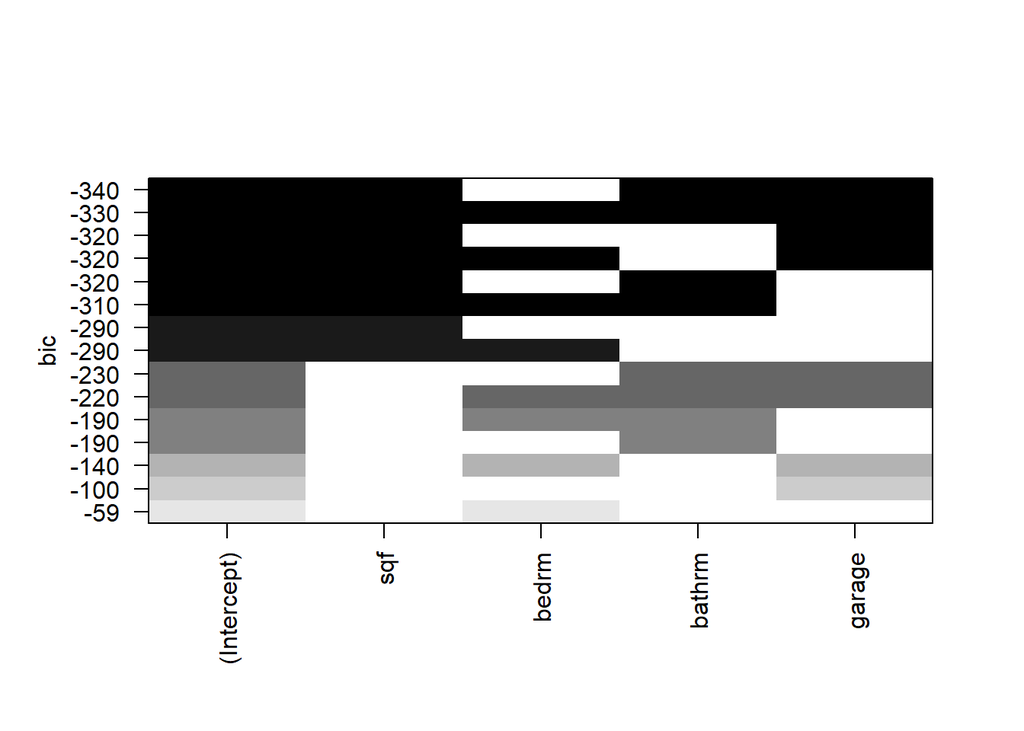

```r
plot(sub_set)
```

We need to calculate the model *AIC* or *BIC* manually:

```r
p.m <- rowSums(sum_sub$which) #number of coefficients in each model: p
ssto <- sum((train$y-mean(train$y))^2)
sse <- (1-sum_sub$rsq)*ssto
aic <- n*log(sse/n)+2*p.m
bic <- n*log(sse/n)+log(n)*p.m
res_sub <- cbind(sum_sub$which, sse, sum_sub$rsq, sum_sub$adjr2,sum_sub$cp, bic, aic)
```

The `regsubsets` function does not fit the none-model with no X variable, so we will have to do it manually:

```r
fit0 <- lm(y ~ 1, data = train)  #none-model: intercept only
full <- lm(y ~ sqf + bedrm + bathrm + garage, data = train)  #full model
sse0 <- sum(fit0$residuals^2)
p0 <- 1  #only one regression coefficient
c0 <- sse0/summary(full)$sigma^2 - (n - 2 * p0)
aic0 <- n * log(sse0/n) + 2 * p0
bic0 <- n * log(sse0/n) + log(n) * p0
none <- c(1, 0, 0, 0, 0, sse0, 0, 0, c0, bic0, aic0)  #model summary for intercept model
```

Let us now combine all the results:

```r
# combine the results
res_sub <- rbind(none, res_sub)
colnames(res_sub) <- c(colnames(sum_sub$which), "sse", "R^2", "R^2_a", "Cp", "bic",
    "aic")
round(res_sub, 2)
```

```
##      (Intercept) sqf bedrm bathrm garage   sse  R^2 R^2_a     Cp     bic
## none           1   0     0      0      0 44.01 0.00  0.00 763.42 -459.02
## 1              1   1     0      0      0 13.71 0.69  0.69  61.57 -757.81
## 1              1   0     0      1      0 20.62 0.53  0.53 221.96 -651.38
## 1              1   0     0      0      1 28.30 0.36  0.35 400.48 -568.69
## 1              1   0     1      0      0 33.63 0.24  0.23 524.28 -523.67
## 2              1   1     0      0      1 11.92 0.73  0.73  21.88 -788.85
## 2              1   1     0      1      0 12.34 0.72  0.72  31.76 -779.70
## 2              1   1     1      0      0 13.71 0.69  0.69  63.52 -752.29
## 2              1   0     0      1      1 17.38 0.61  0.60 148.82 -690.35
## 2              1   0     1      1      0 20.18 0.54  0.54 213.75 -651.44
## 2              1   0     1      0      1 24.47 0.44  0.44 313.53 -601.07
## 3              1   1     0      1      1 11.09 0.75  0.75   4.60 -802.12
## 3              1   1     1      0      1 11.92 0.73  0.73  23.81 -783.35
## 3              1   1     1      1      0 12.29 0.72  0.72  32.57 -775.22
```

[output cut: 19 more lines]

We can see that the models are sorted (ranked) according to SSE within each model size group.

We can option the plots of the criteria. A solid line connects the values of the best model for each model size.

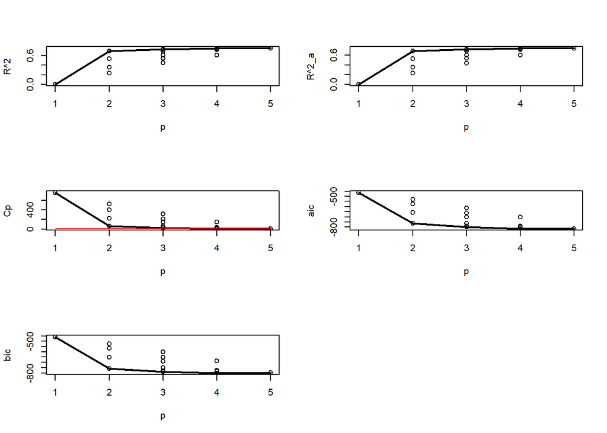

```r
p.plot <- res_sub[, 1] + res_sub[, 2] + res_sub[, 3] + res_sub[, 4] + res_sub[, 5]
res.sub.plot <- as.data.frame(cbind(p.plot, res_sub))
best.plot <- res.sub.plot[c(1, 2, 6, 12, 16), ]
par(mfrow = c(3, 2))
plot(res.sub.plot$p.plot, res.sub.plot$`R^2`, xlab = "p", ylab = "R^2")
lines(best.plot$p.plot, best.plot$`R^2`, lwd = 2)

plot(res.sub.plot$p.plot, res.sub.plot$`R^2_a`, xlab = "p", ylab = "R^2_a")
lines(best.plot$p.plot, best.plot$`R^2_a`, lwd = 2)

plot(res.sub.plot$p.plot, res.sub.plot$Cp, xlab = "p", ylab = "Cp")
lines(best.plot$p.plot, best.plot$Cp, lwd = 2)
lines(best.plot$p.plot, best.plot$p.plot, col = "red")

plot(res.sub.plot$p.plot, res.sub.plot$aic, xlab = "p", ylab = "aic")
lines(best.plot$p.plot, best.plot$aic, lwd = 2)

plot(res.sub.plot$p.plot, res.sub.plot$bic, xlab = "p", ylab = "bic")
lines(best.plot$p.plot, best.plot$bic, lwd = 2)

par(mfrow = c(1, 1))
```

For the $C_p$ plot, good models should be nearby or below the red line $C_p = p$, indicating small model bias, and should have small $C_p$ values, indicating a simple model (so less model variance).

One other criteria is the $Press_p$ using formula
$$Press_p = \sum_{i=1}^n \frac{(Y_i-\hat{Y}_i)^2}{(1-h_{ii})^2}$$
where $h_{ii}$ is the $i$-th diagonal element of the hat matrix $H$ (using all $n$ cases). For example, we can get the $Press_p$ values for the none-model and the full model.

```r
PRESS_none <- sum((fit0$residuals/(1-influence(fit0)$hat))^2)
PRESS_full <- sum((full$residuals/(1-influence(full)$hat))^2)
PRESS_none
```

```
## [1] 44.35251
```

```r
PRESS_full
```

```
## [1] 11.63904
```

The function `infuence(fit)$hat` gives us the diagonal of the “hat matrix” of a regression model. Models with small $Press_p$ values are considered to have good predictive ability.

## Stepwise Regression

We can also try to find the “best model” sequentially using stepwise regression procedures.

- **Forward selection**: Start from a simple model (normally the intercept only model), and add variables that give the biggest improvement of the criterion. Repeat the process until the criterion can not be improved by adding a variable.
- **Backward elimination**: Start from a full model and delete variables that give the biggest improvement of the criterion. Repeat the process until the criterion can not be improved anymore.
- **Forward or Backward stepwise**: At each step, evaluate all possible additions and deletions of a single variable, and choose the action that improves the criterion the most (it may be an addition or a deletion). Repeat until no improvement can be made.

```r
none_mod <- lm(y ~ 1, data = train)  ##model with only intercept
full_mod <- lm(y ~ sqf + bedrm + bathrm + garage + factor(AC) + factor(pool) + factor(quality) +
    factor(style) + factor(hw), data = train)  ##first order model with 9 predictors
library(MASS)

# forward selection based on AIC:
stepAIC(none_mod, scope = list(upper = full_mod, lower = ~1), direction = "forward",
    k = 2, trace = FALSE)
```

```
##
## Call:
## lm(formula = y ~ sqf + factor(quality) + garage + bathrm + factor(AC),
##     data = train)
##
## Coefficients:
##      (Intercept)               sqf  factor(quality)2  factor(quality)3
##       11.7914206         0.0002594        -0.3059785        -0.4378812
##           garage            bathrm       factor(AC)1
##        0.0773567         0.0608845         0.0505922
```

```r
# backward elimination based on AIC
stepAIC(full_mod, scope = list(upper = full_mod, lower = ~1), direction = "backward",
    k = 2, trace = FALSE)
```

```
##
## Call:
## lm(formula = y ~ sqf + bathrm + garage + factor(AC) + factor(quality),
##     data = train)
##
## Coefficients:
##      (Intercept)               sqf            bathrm            garage
##       11.7914206         0.0002594         0.0608845         0.0773567
##      factor(AC)1  factor(quality)2  factor(quality)3
##        0.0505922        -0.3059785        -0.4378812
```

```r
# forward stepwise based on AIC
stepAIC(none_mod, scope = list(upper = full_mod, lower = ~1), direction = "both",
    k = 2, trace = FALSE)
```

```
##
## Call:
## lm(formula = y ~ sqf + factor(quality) + garage + bathrm + factor(AC),
##     data = train)
##
## Coefficients:
##      (Intercept)               sqf  factor(quality)2  factor(quality)3
##       11.7914206         0.0002594        -0.3059785        -0.4378812
##           garage            bathrm       factor(AC)1
##        0.0773567         0.0608845         0.0505922
```

```r
# backward stepwise based on AIC
stepAIC(full_mod, scope = list(upper = full_mod, lower = ~1), direction = "both",
    k = 2, trace = FALSE)
```

```
##
## Call:
## lm(formula = y ~ sqf + bathrm + garage + factor(AC) + factor(quality),
##     data = train)
##
## Coefficients:
##      (Intercept)               sqf            bathrm            garage
##       11.7914206         0.0002594         0.0608845         0.0773567
##      factor(AC)1  factor(quality)2  factor(quality)3
##        0.0505922        -0.3059785        -0.4378812
```

The above models are selected based on AIC. If we want to use BIC, set `k=log(n)`

```r
# selection based on BIC: set option 'k=log(n)'
stepAIC(none_mod, scope = list(upper = full_mod, lower = ~1), direction = "forward",
    k = log(n), trace = FALSE)
```

```
##
## Call:
## lm(formula = y ~ sqf + factor(quality) + garage + bathrm, data = train)
##
## Coefficients:
##      (Intercept)               sqf  factor(quality)2  factor(quality)3
##       11.8259425         0.0002584        -0.3061921        -0.4508661
##           garage            bathrm
##        0.0845816         0.0606846
```

```r
stepAIC(full_mod, scope = list(upper = full_mod, lower = ~1), direction = "backward",
    k = log(n), trace = FALSE)
```

```
##
## Call:
## lm(formula = y ~ sqf + bathrm + garage + factor(quality), data = train)
##
## Coefficients:
##      (Intercept)               sqf            bathrm            garage
##       11.8259425         0.0002584         0.0606846         0.0845816
## factor(quality)2  factor(quality)3
##       -0.3061921        -0.4508661
```

```r
stepAIC(none_mod, scope = list(upper = full_mod, lower = ~1), direction = "both",
    k = log(n), trace = FALSE)
```

```
##
## Call:
## lm(formula = y ~ sqf + factor(quality) + garage + bathrm, data = train)
##
## Coefficients:
##      (Intercept)               sqf  factor(quality)2  factor(quality)3
##       11.8259425         0.0002584        -0.3061921        -0.4508661
##           garage            bathrm
##        0.0845816         0.0606846
```

```r
stepAIC(full_mod, scope = list(upper = full_mod, lower = ~1), direction = "both",
    k = log(n), trace = FALSE)
```

```
##
## Call:
## lm(formula = y ~ sqf + bathrm + garage + factor(quality), data = train)
##
## Coefficients:
##      (Intercept)               sqf            bathrm            garage
##       11.8259425         0.0002584         0.0606846         0.0845816
## factor(quality)2  factor(quality)3
##       -0.3061921        -0.4508661
```

For the full model definition, if we want to use the 1st-order model with all predictors, we can write “y~.” in *lm()*. If we write “y~.^2”, it means the model with all first order terms and all 2-way interactions. While using these *short-hand formulae*, we should first transform the type of categorical variables into *factor*.

The “scope” option tells R to search the pool of models from the none-model, but does not go beyond the full model. If we want to always keep a couple variables, say X1 and X2, in all the models being considered, we need to specify `scope=list(lower= X1+X2)`.

Here `direction="forward"` means forward selection. Other options are `direction="backward"` (backward elimination) or `direction="both"` (forward or backward stepwise depending whether you start with a none-model or a full-model).

By default, the `stepAIC` function uses *AIC*, if we set option `k=log(n)`, it will select models based on *BIC*.

If we do not want to see the print out at each step, set option `trace = FALSE`.

Below we show the detailed output of the forward stepwise results using BIC:

```r
stepAIC(none_mod, scope = list(upper = full_mod, lower = ~1), direction = "both",
    k = log(n))
```

```
## Start:  AIC=-459.02
## y ~ 1
##
##                   Df Sum of Sq    RSS     AIC
## + sqf              1   30.2994 13.714 -757.81
## + factor(quality)  2   26.7417 17.272 -692.04
## + bathrm           1   23.3949 20.618 -651.38
## + garage           1   15.7100 28.303 -568.69
## + bedrm            1   10.3806 33.633 -523.67
## + factor(style)    7   10.5002 33.513 -491.21
## + factor(AC)       1    4.7512 39.262 -483.27
## <none>                         44.013 -459.02
## + factor(pool)     1    0.5824 43.431 -456.93
## + factor(hw)       1    0.0889 43.924 -453.99
##
## Step:  AIC=-757.81
## y ~ sqf
##
##                   Df Sum of Sq    RSS     AIC
## + factor(quality)  2    3.7505  9.963 -830.06
## + garage           1    1.7946 11.919 -788.85
## + bathrm           1    1.3693 12.345 -779.70
## + factor(AC)       1    0.7936 12.920 -767.80
## <none>                         13.714 -757.81
## + factor(pool)     1    0.0405 13.673 -753.01
## + factor(hw)       1    0.0231 13.691 -752.68
## + bedrm            1    0.0024 13.712 -752.29
## + factor(style)    7    1.2954 12.419 -744.75
## - sqf              1   30.2994 44.013 -459.02
##
## Step:  AIC=-830.06
## y ~ sqf + factor(quality)
##
##                   Df Sum of Sq     RSS     AIC
## + garage           1    0.5495  9.4140 -839.30
## + bathrm           1    0.5421  9.4214 -839.10
## <none>                          9.9634 -830.06
## + factor(AC)       1    0.1722  9.7913 -829.05
## + bedrm            1    0.0964  9.8670 -827.04
## + factor(hw)       1    0.0233  9.9402 -825.11
```

[output cut: 19 more lines]

```
##
## Step:  AIC=-845.15
## y ~ sqf + factor(quality) + garage + bathrm
##
##                   Df Sum of Sq     RSS     AIC
## <none>                          9.0114 -845.15
## + factor(AC)       1   0.08047  8.9309 -841.92
## + factor(pool)     1   0.01785  8.9936 -840.10
## + factor(hw)       1   0.01193  8.9995 -839.93
## + bedrm            1   0.00798  9.0034 -839.81
## - bathrm           1   0.40255  9.4140 -839.30
## - garage           1   0.40997  9.4214 -839.10
## + factor(style)    7   0.43133  8.5801 -819.00
## - factor(quality)  2   2.07796 11.0894 -802.12
## - sqf              1   3.00490 12.0163 -775.60
```

```
##
## Call:
## lm(formula = y ~ sqf + factor(quality) + garage + bathrm, data = train)
##
## Coefficients:
##      (Intercept)               sqf  factor(quality)2  factor(quality)3
##       11.8259425         0.0002584        -0.3061921        -0.4508661
##           garage            bathrm
##        0.0845816         0.0606846
```

## Model Validation

The “best” model based on forward selection, backward elimination and forward or Backward stepwise with BIC is “log(price) ~ sqf + garage + bathrm + factor(quality)”.

The validation data is used to re-run this model.

```r
train1 <- lm(y ~ sqf + garage + bathrm + factor(quality), data = train)
valid1 <- lm(y ~ sqf + garage + bathrm + factor(quality), data = valid)

mod_sum <- cbind(coef(summary(train1))[, 1], coef(summary(valid1))[, 1], coef(summary(train1))[,
    2], coef(summary(valid1))[, 2])
colnames(mod_sum) <- c("Train Est", "Valid Est", "Train s.e.", "Valid s.e.")
```

And we have the following comparison:

```r
mod_sum
```

```
##                     Train Est     Valid Est   Train s.e.   Valid s.e.
## (Intercept)      11.825942455 11.9155283592 0.0994083413 9.742887e-02
## sqf               0.000258401  0.0002629832 0.0000280224 2.992737e-05
## garage            0.084581642  0.0599368257 0.0248328443 2.111205e-02
## bathrm            0.060684592  0.0577776019 0.0179802623 1.945076e-02
## factor(quality)2 -0.306192122 -0.3466342744 0.0474943782 4.367501e-02
## factor(quality)3 -0.450866073 -0.5202047114 0.0587974752 6.067856e-02
```

Most of the estimated coefficients as well as their standard errors agree quite closely on the two data sets.

We can also examine the SSE and adjusted R squares using both the training data and validation data.

```r
sse_t <- sum(train1$residuals^2)
sse_v <- sum(valid1$residuals^2)
Radj_t <- summary(train1)$adj.r.squared
Radj_v <- summary(valid1)$adj.r.squared
train_sum <- c(sse_t,Radj_t)
valid_sum <- c(sse_v,Radj_v)
criteria <- rbind(train_sum,valid_sum)
colnames(criteria) <- c("SSE","R2_adj")
criteria
```

```
##                SSE    R2_adj
## train_sum 9.011413 0.7912425
## valid_sum 9.616164 0.8133869
```

The SSE and adjusted R squares are also very close.

Now what we’d like to do is find the $SSE/n$ under the training model, and compare it to the $MSPE_v$ when we apply our training model to the validation data. The idea here is that if $SSE/n$ is close to $MSPE_v$, then there is no severe overfitting by the model. If $MSPE_v$ is much larger than $SSE/n$, then there is some evidence of overfitting with the training data, and so we should use $MSPE_v$ as an indicator of the predictive ability of the model.

Now what we have to do is to use the estimated coefficients from the training fit, and apply them to get fitted values for the validation set.

```r
#Get MSPE_v from new data
newdata <- valid[, -1]
y.hat <- predict(train1, newdata)
```

Now that we have the fitted values for the validation set (using the estimated coefficients from the training set), we can find $MSPE_v$. We have that:
$$MSPE_v = \frac{\sum_{j=1}^m(Y_j-\hat{Y}_j)^2}{m}$$
Where $Y_j$ is the $j$-th observation from the validation set, $\hat{Y}_j$ is the $j$-th fitted value, and $m$ is the number of observations in the validation set. In R, we can find it this way:

```r
MSPE <- mean((valid$y - y.hat)^2)
MSPE
```

```
## [1] 0.03722412
```

```r
sse_t/n
```

```
## [1] 0.03452649
```

We conclude that since $MSPE_v$ is close to $SSE/n$, there is no severe overfitting in the model.